# Habitat verification OCLEE

B. Maranget

30/04/2026

# 1 Objet

Vérifier les données de l’OCLEE (Outil de suivi de la Construction des Logements d’Est Ensemble) = fichier annuel

Dans le mail, il est indiqué :

- en priorité livraison 2025 et après
- état programmation différent de livré

Il est nécessaire de trouver un process puisque cette vérification intervient tous les ans.

Idées :

- filtre fait sur le tableau
- croiser RIL (connaissance terrain), données urba (données plus récentes) avec l’OCLEE
- cartographier les plus gros projets

# 2 La donnée

```
## Driver: GPKG
## Available layers:
##         layer_name geometry_type features fields              crs_name
## 1 cadastreParcelle Multi Polygon     7028     17 RGF93 v1 / Lambert-93
## 2              LCV Multi Polygon      259     18 RGF93 v1 / Lambert-93
## 3               LH Multi Polygon      114     18 RGF93 v1 / Lambert-93
## 4              PNB Multi Polygon       73     39 RGF93 v1 / Lambert-93
## 5  matriceDistance         Point      503      6 RGF93 v1 / Lambert-93
## 6             bndb                   8188      4 RGF93 v1 / Lambert-93
## 7             rnic         Point      332     71                WGS 84
```

```
## Driver: GPKG
## Available layers:
##         layer_name geometry_type features fields              crs_name
## 1             anru       Polygon        7      2 RGF93 v1 / Lambert-93
## 2              qpv       Polygon        7      3 RGF93 v1 / Lambert-93
## 3         cadastre       Polygon      106      6 RGF93 v1 / Lambert-93
## 4         filosofi                     29     29 RGF93 v1 / Lambert-93
## 5             bndb                    150      7 RGF93 v1 / Lambert-93
## 6              poi         Point        7      7 RGF93 v1 / Lambert-93
## 7              ban         Point      363     24 RGF93 v1 / Lambert-93
## 8          pmorale                     65      6 RGF93 v1 / Lambert-93
## 9              bat                    333     30 RGF93 v1 / Lambert-93
## 10             ril         Point      340     10 RGF93 v1 / Lambert-93
## 11             bpe         Point      176      9 RGF93 v1 / Lambert-93
## 12            rpls         Point       92      9 RGF93 v1 / Lambert-93
## 13             icu Multi Polygon       49     18 RGF93 v1 / Lambert-93
## 14             rue                    104      9 RGF93 v1 / Lambert-93
## 15          espPub                      5     50 RGF93 v1 / Lambert-93
## 16           copro         Point        8      7 RGF93 v1 / Lambert-93
## 17        iris2021 Multi Polygon       22     35 RGF93 v1 / Lambert-93
## 18            zone       Polygon        7     15 RGF93 v1 / Lambert-93
## 19             poc         Point      547    312 RGF93 v1 / Lambert-93
## 20   ocleeQuartier   Multi Point       98     84                WGS 84
## 21           oclee         Point       75     83                WGS 84
## 22   parcelleOclee Multi Polygon       45    103 RGF93 v1 / Lambert-93
## 23 prioriteTerrain         Point       41      6 RGF93 v1 / Lambert-93
```

## 2.1 OCLEE

Présentation filtre dans le SIG EE

### 2.1.1 Filtre

filtre = 83 obs (202 au départ)

## 2.2 Données obtenues

### 2.2.1 OCLEE et parcelle

45 projets avec parcelle

### 2.2.2 Donnée géocodée

75 projets géocodés à l’adresse

[interactive chart not shown]

## 2.3 Identification parcelle 1 pour l’OCLEE

Extraction section et parcelle 1

```
##  [1] "AV"   "A"    "AE"   "F"    "V"    "AM"   "AM"   "AM"   NA     NA
## [11] "K105" "F"    "AV"   "F"    "J"    "AU"   "BC"   "G"    "N"    "K"
## [21] "L"    "AN"   "AG"   NA     "BF"   "AG"   "AY"   NA     NA     "F"
## [31] NA     "Y"    "AD"   "AE"   NA     "M"    "F"    "O"    "AS"   "AN"
## [41] "V"    "BH"   "AS"   "AG"   NA     NA     "J"    "AU"   "AO"   NA
## [51] NA     "C"    NA     NA     NA     NA     NA     NA     NA     NA
## [61] NA     "H"    NA     NA     NA     "H"    NA     "AT"   "G"    NA
## [71] NA     NA     NA     NA     NA     NA     NA     NA     NA     NA
## [81] NA     NA     NA
```

```
##  [1] "140" "190" "209" "108" "24"  "32"  "16"  "40"  NA    NA    "107" "188"
## [13] "73"  "108" "4"   "20"  "75"  "119" "6"   "54"  "90"  "55"  "146" NA
## [25] "103" "144" "157" NA    NA    "155" NA    "82"  "82"  "28"  NA    "18"
## [37] "86"  "2"   "215" "103" "107" "44"  "64"  "85"  NA    NA    "18"  "9"
## [49] "133" NA    NA    "179" NA    NA    NA    NA    NA    NA    NA    NA
## [61] NA    "90"  NA    NA    NA    "142" NA    "178" "173" NA    NA    NA
## [73] NA    NA    NA    NA    NA    NA    NA    NA    NA    NA    NA
```

```
##  [1] "AV140"   "A190"    "AE209"   "F108"    "V24"     "AM32"    "AM16"
##  [8] "AM40"    "NANA"    "NANA"    "K105107" "F188"    "AV73"    "F108"
## [15] "J4"      "AU20"    "BC75"    "G119"    "N6"      "K54"     "L90"
## [22] "AN55"    "AG146"   "NANA"    "BF103"   "AG144"   "AY157"   "NANA"
## [29] "NANA"    "F155"    "NANA"    "Y82"     "AD82"    "AE28"    "NANA"
## [36] "M18"     "F86"     "O2"      "AS215"   "AN103"   "V107"    "BH44"
## [43] "AS64"    "AG85"    "NANA"    "NANA"    "J18"     "AU9"     "AO133"
## [50] "NANA"    "NANA"    "C179"    "NANA"    "NANA"    "NANA"    "NANA"
## [57] "NANA"    "NANA"    "NANA"    "NANA"    "NANA"    "H90"     "NANA"
## [64] "NANA"    "NANA"    "H142"    "NANA"    "AT178"   "G173"    "NANA"
## [71] "NANA"    "NANA"    "NANA"    "NANA"    "NANA"    "NANA"    "NANA"
## [78] "NANA"    "NANA"    "NANA"    "NANA"    "NANA"    "NANA"
```

A corriger manque espace dans K105

## 2.4 Géocodage

C’est le fait de récupérer la localisation cartographique.

On cherche à partir de l’adresse, puis de la parcelle.

Enfin, on peut comparer avec le résultat obtenu par Est Ensemble puisque la donnée OCLEE est géolocalisée.

### 2.4.1 Méthode 1 : à partir de l’adresse

```
## Writing tempfile to...C:\Users\BMARAN~1\AppData\Local\Temp\RtmpU1YpLz\file2c442004339.csv
```

```
## If file is larger than 50 MB, it must be splitted
## Size is : 2.2 Kb
```

```
## SuccessOKSuccess: (200) OK
```

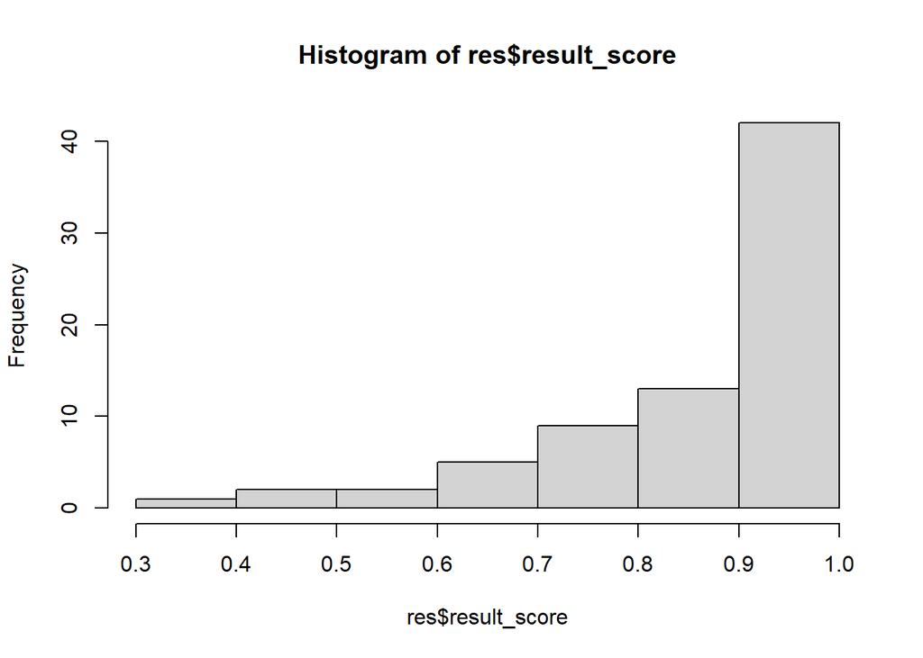

```
## # A tibble: 11 × 22
##          z x             y     longitude latitude result_score result_score_next
##      <dbl> <chr>         <chr>     <dbl>    <dbl>        <dbl> <chr>
##  1 NA      <NA>          <NA>      NA        NA         NA     <NA>
##  2  0.211  129-139 aven… 93010      2.48     48.9        0.643 <NA>
##  3  0.374  18-26 rue Bo… 93010      2.49     48.9        0.403 0.30505297520661…
##  4  0.391  26-30 avenue… 93010      2.48     48.9        0.672 0.32105151515151…
##  5  0.473  3-7 avenue P… 93010      2.48     48.9        0.444 <NA>
##  6 -0.881  4 rue des Ci… 93010      2.49     48.9        0.665 <NA>
##  7 -1.22   Avenue de La… 93010      2.48     48.9        0.632 <NA>
##  8  0.0953 Avenue de La… 93010      2.48     48.9        0.632 <NA>
##  9  1.05   Chemin Latér… 93010      2.48     48.9        0.310 <NA>
## 10 -0.670  Rue du Vieux… 93010      2.48     48.9        0.536 <NA>
## 11 -0.892  voie nouvelle 93010      2.49     48.9        0.543 <NA>
## # ℹ 15 more variables: result_label <chr>, result_type <chr>, result_id <chr>,
## #   result_banId <chr>, result_housenumber <chr>, result_name <chr>,
## #   result_street <chr>, result_postcode <chr>, result_city <chr>,
## #   result_context <chr>, result_citycode <chr>, result_oldcitycode <chr>,
## #   result_oldcity <chr>, result_district <chr>, result_status <chr>
```

75 adresses géocodées sur 83 lignes

64 sans doublons

#### 2.4.1.1 Attention à l’apostrophe

```
## [1] "12 rue de l'Union" "58 route d'Aulnay"
```

2 adresses non géocodées ?

```
## # A tibble: 2 × 22
##        z x               y     longitude latitude result_score result_score_next
##    <dbl> <chr>           <chr>     <dbl>    <dbl>        <dbl> <chr>
## 1 -0.134 12 rue de l Un… 93010      2.49     48.9        0.966 <NA>
## 2 -1.94  58 route d Aul… 93010      2.48     48.9        0.972 <NA>
## # ℹ 15 more variables: result_label <chr>, result_type <chr>, result_id <chr>,
## #   result_banId <chr>, result_housenumber <chr>, result_name <chr>,
## #   result_street <chr>, result_postcode <chr>, result_city <chr>,
## #   result_context <chr>, result_citycode <chr>, result_oldcitycode <chr>,
## #   result_oldcity <chr>, result_district <chr>, result_status <chr>
```

#### 2.4.1.2 Doublons d’adresse et absence d’adresses = demande d’informations à faire ?

##### 2.4.1.2.1 Doublons

```
##                              adr                  nom_prog ann_lvr  mod_prod
## 160            58 route d'Aulnay Restructuration FTM Ourcq    2027        CN
## 161            58 route d'Aulnay Restructuration FTM Ourcq    2027     DEMOL
## 166  8-10 rue Martin Luther King          Démolition bat B    2026     DEMOL
## 167  8-10 rue Martin Luther King                     Lot 8    2031        CN
## 169        Allee du Gros Buisson                     Lot 4    2029        CN
## 170        Allee du Gros Buisson                     Lot 3    2029        CN
## 171 Avenue de Lattre de Tassigny     Réhabilitation bat A1    2027 REHAB LLS
## 172 Avenue de Lattre de Tassigny            Foncier bat A1    2027        CN
## 174           Avenue Jean Moulin     Démolition bat J et K    2027     DEMOL
## 175           Avenue Jean Moulin          Démolition bat M    2027     DEMOL
## 176           Avenue Jean Moulin        Démolition bat L1     2029     DEMOL
## 177           Avenue Jean Moulin         Démolition bat L2    2030     DEMOL
## 180         Route de Villemomble                     Lot 1    2028        CN
## 181         Route de Villemomble                     Lot 2    2029        CN
```

[output cut: 25 more lines]

##### 2.4.1.2.2 Absence d’adresse

```
##     adr      nom_ssect                  nom_ope nom_prog ann_lvr mod_prod
## 194     Secteur Salins ZAC des Rives de l'Ourcq  Lot S4b    2030       CN
## 195     Secteur Salins ZAC des Rives de l'Ourcq   Lot S5    2030       CN
## 196     Secteur Salins ZAC des Rives de l'Ourcq   Lot S3    2030       CN
## 197     Secteur Salins ZAC des Rives de l'Ourcq  Lot S4a    2030       CN
## 198                               NPNRU Blanqui Lot 4 AB    2031       CN
## 199                               NPNRU Blanqui    Lot 6    2031       CN
## 200                               NPNRU Blanqui    Lot 7    2031       CN
## 201                               NPNRU Blanqui   Lot 4C    2031       CN
##                                                                                                       rem
## 194 reprogrammation suite audit / densité S3 S4 S5 réduite de 22% SDP / fléchage RO SSDH /prog à préciser
## 195 reprogrammation suite audit / densité S3 S4 S5 réduite de 22% SDP / fléchage RO SSDH /prog à préciser
## 196 reprogrammation suite audit / densité S3 S4 S5 réduite de 22% SDP / fléchage RO SSDH /prog à préciser
## 197                   reprogrammation suite audit / densité S3 S4 S5 réduite de 22% SDP / prog à préciser
## 198                                                                   actualisation plan guide avril 2025
## 199                                                                   actualisation plan guide avril 2025
## 200                                                                   actualisation plan guide avril 2025
## 201                                                                   actualisation plan guide avril 2025
```

8 lignes sans adresse (ni parcelle d’ailleurs)

##### 2.4.1.2.3 Eléments trouvés dans la convention anru de juin 2024 pour les lots et les bâtiments

```
## Driver: GPKG
## Available layers:
##         layer_name    geometry_type features fields              crs_name
## 1             anru          Polygon        1      1 RGF93 v1 / Lambert-93
## 2 parcelleSabliere   3D Line String        7      2 RGF93 v1 / Lambert-93
## 3      lotSablière 3D Multi Polygon        7      2 RGF93 v1 / Lambert-93
```

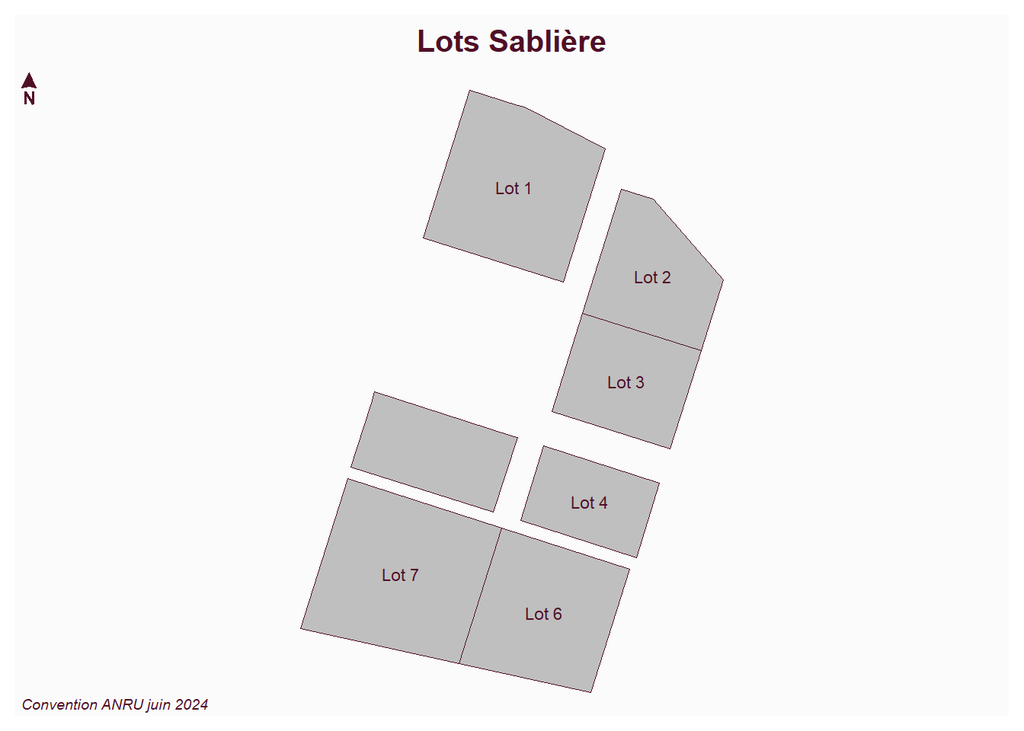

```
## The scale bar does not work on unprojected (long/lat) maps.
```

TODO récupérer Autocad Blanqui

bâtiments

requête OS% :

```
name~'bat' and building=yes in bondy
```

[interactive chart not shown]

#### 2.4.1.3 Jointure table d’adresse et données

pour mémoire, 75 adresses trouvées, 64 uniques

Attention correction une adresse dans le fichier originale

[interactive chart not shown]

A noter la voie nouvelle a été placé sur Andrei Sakharov (elle est sur Blanqui)

TODO erreurs de géocodage

### 2.4.2 Méthode 2 : à la parcelle

Utiliser cette méthode permet de prendre conscience des modifications du cadastre. Par exemple, 242 modifications de parcelles sur 2025-26 Ces modifications interviennent souvent en rapport avec les constructions.

[interactive chart not shown]

On récupère la version du cadastre avec adresse

attention la seule disponible est dans cadastre2024.gpkg parcelle_info

TODO import dans base tt

```
##   geo_section tex  code
## 1 9300100000A   8 A0008
## 2 9300100000A   9 A0009
## 3 9300100000A  10 A0010
## 4 9300100000A  11 A0011
## 5 9300100000A  12 A0012
## 6 9300100000A  13 A0013
```

```
##
## FALSE
##  7124
```

46 parcelles / 45

```
## [1] "K105107" "AY157"
```

2 erreurs déjà connues

[interactive chart not shown]

```
## Deleting layer `parcelleOclee' using driver `GPKG'
## Writing layer `parcelleOclee' to data source
##   `../data/habitat2026.gpkg' using driver `GPKG'
## Writing 45 features with 103 fields and geometry type Multi Polygon.
```

2 références adresse cadastre et oclee = quelles corrections ?

| adresse | adr | code |
| --- | --- | --- |
| 111 RTE D AULNAY | 1 rue de Versailles - Avenue Henri Vagnat | A0190 |
| 6 SQ DU HUIT MAI 1945 | 26-30 avenue Carnot | AD0082 |
| 1 RUE JEAN JAURES | 1 rue Jean Jaurès | AE0209 |
| 27 RUE DU BREUIL | 27 rue du Breuil | AE0028 |
| 200 AV DE ROSNY | 200 avenue de Rosny | AG0144 |
| 196 AV DE ROSNY | 196 avenue de Rosny | AG0146 |
| 5 RUE DU POTAGER | 5 rue du Potager | AG0085 |
| 12 RUE DE L UNION | 12 rue de l’Union | AM0016 |
| 119 RUE EDOUARD VAILLANT | 119 bis rue Edouard Vaillant | AM0032 |
| 121 RUE EDOUARD VAILLANT | 121 rue Edouard Vaillant | AM0040 |
| 4 ALL DE LA PAIX | 4 allée de la Paix | AN0103 |
| 19 ALL DE LA VILLA JEANNETTE | 19 allée de la Villa Jeannette | AN0055 |
| 7 ALL RACINE | 7 allée Racine | AO0133 |
| 3 AV DENISE | 3bis Avenue Denise | AS0215 |
| 48 RUE EDOUARD VAILLANT | 48 rue Edouard Vaillant | AS0064 |
| RUE DU VIEUX MOULIN | Rue du Vieux Moulin / Rue du Sergent Bobillot | AT0178 |
| 1 ALL SURCOUF | 15-25 avenue Jules Ferry | AU0020 |
| 10 AV JULES FERRY | 6-10 avenue Jules Ferry | AU0009 |
| 1 ALL DES HETRES | 1 allée des Hetres | AV0140 |
| 15 AV DES PLATANES | 15 avenue des Platanes | AV0073 |
| 142 RTE DE VILLEMOMBLE | 156-168 Route de Villemomble | BC0075 |
| 20 AV DE BELFORT | 20 avenue de Belfort | BF0103 |
| 42 RUE ETIENNE DOLET | 42 rue Etienne Dolet | BH0044 |
| 13 AV MARX DORMOY | 9-13 avenue Marx Dormoy | C0179 |
| 35 RUE FONTAINE | 10 avenue Marx Dormoy | F0108 |
| 35 RUE FONTAINE | 1-5 Rue Athur Groussier | F0108 |
| 35 RUE FONTAINE | 10 avenue Marx Dormoy | F0108 |
| 35 RUE FONTAINE | 1-5 Rue Athur Groussier | F0108 |
| 25 RUE FONTAINE | 25 rue Fontaine | F0155 |
| 11 AV DE LA PARISIENNE | 14 rue Lucien Chapelain | F0188 |
| 40 RUE FONTAINE | 36 rue Fontaine | F0086 |
| 17 AV DES MESARMES | 17 avenue des Mesarmes | G0119 |
| 32 RTE D AULNAY | Rue Françoise Héritier | G0173 |
| 35 CHE LATERAL | Rue Aretha Franklin | H0142 |
| 3 CHE LATERAL | Chemin Latéral | H0090 |
| 78 AV GALLIENI | 60-70 avenue Gallieni | J0018 |
| 17 RUE GATINE | 15-17 rue Gâtine | J0004 |
| 18 AV MARGUERITE | 18 avenue Marguerite | K0054 |
| 24 RUE BOREL | 18-26 rue Borel / 11-15 rue Laug | L0090 |
| 44 RUE GEORGES ELIE | 30-44 rue Georges Elie | M0018 |
| 174 AV GALLIENI | 172-174 avenue Gallieni | N0006 |
| 49 AV MAL DE LATTRE DE TASSIGNY | 3-7 avenue Pasteur / 45-49 avenue du Maréchal de Lattre Tassigny | O0002 |
| 2 RUE DE PRESSENSE | 4 rue des Cinq Ormes | V0107 |
| 113 AV HENRI BARBUSSE | 113 avenue Henri Barbusse | V0024 |
| 26 RUE RAOUL | 26 rue Raoul | Y0082 |

A noter également, les changements de nom de rue

- chemin latéral devient av. jean baptiste de villers
- adressage fairplay, zac ourcq
- pb adresse sur 1-5 Arthur Groussier

[interactive chart not shown]

F108 cadastre millesime 2025 (marx dormoy) cf Arcopole

AY157

```
## [1] "21 Rue de Tremeuge"
```

A corriger c’est Y157

### 2.4.3 Méthode 3 : récupérer la couche Observatoire

Comment a été faite la géolocalisation ?

### 2.4.4 Remarques

Cette étude a permis, dans le tableau à modifier de :

- correction de 2 éléments au niveau de la parcelle
- précision sur les adresses (étude des doublons)

# 3 ADS : données logiciel Operis

Pour mémoire, export Operis en faisant “Bondy” dans la recherche avanncée = 500 dossiers en limite, vaut mieux passer par statis

```
##
##        AP   AT   CU   DP   PA   PC   PD
##    1    4  204 2178 1020    3  481   43
```

```
## annee
##   9  13  14  15  16  17  18  19  20  21  22  23  24  25  26
##   1   1   2   6   1   6   6   9  27 229 910 849 808 801 277
```

```
##
##           AP  AT  CU  DP  PA  PC  PD
##   9    0   0   0   0   0   0   1   0
##   13   0   0   0   0   0   0   1   0
##   14   0   0   0   0   0   0   2   0
##   15   0   0   0   0   0   0   6   0
##   16   0   0   0   0   0   0   1   0
##   17   0   0   0   0   0   0   6   0
##   18   0   0   0   0   0   0   6   0
##   19   0   0   0   0   0   0   9   0
##   20   0   0   0   0   0   0  27   0
##   21   0   0   0   3 120   0 100   6
##   22   0   0  38 584 192   0  89   7
##   23   0   0  53 507 207   1  70  11
##   24   0   0  49 461 212   0  79   7
##   25   0   0  51 460 216   1  68   5
##   26   0   4  13 163  73   1  16   7
```

```
##
##    3    4
##    5 3890
```

```
##               Dossier num
## 1    AP 93010 26 B001   1
## 2    AP 93010 26 B002   2
## 3    AP 93010 26 B003   3
## 4    AP 93010 26 B004   4
## 3127 DP 93010 25 B001   1
```

```
##
## FALSE  TRUE
##  3895    39
```

```
##
## FALSE
##  3934
```

```
##  [1] "013" "016" "024" "025" "027" "029" "031" "051" "204" "205" "206" "350"
## [13] "212" "217" "005" "043" "044" "046" "047" "076" "083" "087" "140" "141"
## [25] "151" "157" "161" "162" "180" "188" "042" "014" "021" "033" "041" "M01"
## [37] "054" "065" ""
```

Dans le logiciel ADS, on a plus que SITADEL, cela vaut-il le coup ?

Exemple sur les numéros de PC : ils existent dans le logiciel de l’urbanisme

## 3.1 pc accordé

manque numéro de PC pour 2 dans les PC accordés

```
##     ville idpc ame_diff typ_ame nom_ope nom_moe mod_prod nom_ssect pnrqad
## 118 Bondy        Diffus                               CN              Non
## 136 Bondy        Diffus                               CN              Non
##                 sect_plui nom_qpv qpv qpv_300m pru1 npnru  nom_prom nom_bail
## 118 CIN Plaine de l'Ourcq Blanqui Oui      Non  Non   Non Cap House
## 136 CIN Plaine de l'Ourcq         Non      Non  Non   Non
##     nom_gest_ofs typ_mou_lls nom_prog                      adr    cad typ_fonc
## 118                                   121 rue Edouard Vaillant  AM 40
## 136                                       20 avenue de Belfort BF 103
##      etat_prog    date_pc ann_pc date_droc ann_droc ann_lvr duree_pc_livr
## 118 PC accordé 30/11/2025   2025                 NA    2028             3
## 136 PC accordé 07/07/2025   2025                 NA    2028             3
##     etat_anru nb_log_crees_.ab. nb_log_livr_.a. nb_log_suppr_.b. log_nc
## 118                           2               2                0     NA
## 136                           5               5                0     NA
##     log_acclib log_acclib_suppr log_brs red_brs log_accsoc log_psla log_lli
## 118          2               NA      NA                  0        0       0
## 136          5               NA      NA                  0        0       0
##     log_lli_suppr lli_al log_lls log_lls_suppr lls_plai lls_plus lls_pls lls_nc
## 118            NA     NA       0            NA                                0
## 136            NA     NA       0            NA                                0
##     ann_agr ann_capl plai_ro plus_ro nb_lls_ro loy_lls log_spe log_lls_spe
## 118               NA                                NA      NA          NA
## 136               NA                                NA      NA          NA
##     typ_log_spe log_matype typ_matype t1 t2 t3 t4 t5p t_nc couconst_hors_pkvrd
## 118                     NA             0  2  0  0   0    0                  NA
## 136                     NA             0  4  1  0   0    0                  NA
##     coucons.incl_pkvrd cf_acclib cf_accpxmait cf_brs cf_psla cf_res_spe cf_lli
## 118                 NA                     NA     NA      NA         NA     NA
## 136                 NA                     NA     NA      NA         NA     NA
##     cflls rem      pers_ref   source  dat_maj section num  cad2
## 118           N Chopin DHRU Sitadel2 janv.-26      AM  40  AM40
## 136           N Chopin DHRU Sitadel2   avr-26      BF 103 BF103
```

Quels sont ces 2 PC ? On regarde dans ADS par rapport aux parcelles

```
##                Dossier        Terrain...Adresse Parcelles.concernées type annee
## 3743 PC 93010 24 B0016         20 AV DE BELFORT                BF103   PC    24
## 3806 PC 93010 24 B0071 121 Rue Edouard Vaillant                 AM40   PC    24
## 3829 PC 93010 25 B0023 121 Rue Edouard Vaillant                 AM40   PC    25
## 3851 PC 93010 25 B0040 121 Rue Edouard Vaillant                 AM40   PC    25
##      num
## 3743  16
## 3806  71
## 3829  23
## 3851  40
```

On rajoute dans le tableau

## 3.2 vérification numéros de PC

Filtre sur les dossiers avec numéros de PC dans OCLEE

```
##
## FALSE  TRUE
##    39    44
```

39 pc / 83 … on vérifie dans ads

La difficulté est la comparaison des numéros de pc, le format est différent

```
## [1] "09301021B0078" "09301016B0069" "09301024B0022" "09301022B0069"
## [5] "09301021B0106" "09301023B0041"
```

```
## [1] "AP 93010 26 B001"  "AP 93010 26 B002"  "AP 93010 26 B003"
## [4] "AP 93010 26 B004"  "AT 93010 22 00013" "AT 93010 22 00016"
```

### 3.2.1 Numéro et année

```
##  [1]  78  69  22  69 106  41   5  72  NA  64 102  10  58 175  NA  57  61  36  20
## [20]   5  48   5  38  71  57  55  17  80  59  59  37  56  47  11  75   5   9  49
## [39]   5
```

```
##     ann_pc                             idpc
## 110   2022                    09301021B0078
## 111   2017                    09301016B0069
## 112   2024                    09301024B0022
## 113   2023                    09301022B0069
## 115   2022                    09301021B0106
## 117   2023                    09301023B0041
## 119   2024                 PD 09301024B0005
## 123   2023                    09301022B0072
## 124   2022                    0930102200041
## 125   2025                    09301024B0064
## 127   2022                    09301021B0102
## 128   2024                 PD 09301023B0010
## 129   2025                    09301024B0058
## 131   2023                 DP 09301023B0175
```

[output cut: 25 more lines]

```
##  [1] "09301021"      "09301016"      "09301024"      "09301022"
##  [5] "09301021"      "09301023"      "PD 09301024"   "09301022"
##  [9] "0930102200041" "09301024"      "09301021"      "PD 09301023"
## [13] "09301024"      "DP 09301023"   "09301022"      "09301022"
## [17] "09301023"      "09301025"      "09301024"      "PD 09301024"
## [21] "09301020"      "PD 09301024"   "09301023"      "09301021"
## [25] "09301024"      "09301021"      "09301025"      "09301020"
## [29] "09301022"      "09301021"      "09301022"      "09301016"
## [33] "09301019"      "09301021"      "09301019"      "PD 09301024"
## [37] "PD 09301023"   "09301025"      "PD 09301024"
```

```
##  [1] "21"      "16"      "24"      "22"      "21"      "23"      "24"
##  [8] "22"      "2200041" "24"      "21"      "23"      "24"      "23"
## [15] "22"      "22"      "23"      "25"      "24"      "24"      "20"
## [22] "24"      "23"      "21"      "24"      "21"      "25"      "20"
## [29] "22"      "21"      "22"      "16"      "19"      "21"      "19"
## [36] "24"      "23"      "25"      "24"
```

```
##
##      16      19      20      21      22 2200041      23      24      25
##       2       2       2       7       6       1       6      10       3
```

### 3.2.2 Type

par défaut dans oclee PC

dans Oclee 10 dossiers en 2024 / dans operis, 808

### 3.2.3 Création de la clé

### 3.2.4 Correspondance

```
##                    Dossier          Terrain...Adresse
## 3468 PC 93010 20 B0080 T01            3 Avenue Denise
## 3501 PC 93010 21 B0055 M01            36 Rue Fontaine
## 3562 PC 93010 21 B0102 M01 15 à 21 Avenue Jules Ferry
## 3563 PC 93010 21 B0102 M02    15 à 21 Rue Jules Ferry
## 3651 PC 93010 22 B0069 T01
## 3798 PC 93010 24 B0064 T01
##                                                                     Parcelles.concernées
## 3468                                                                               AS215
## 3501                                                           F86, F87, F88, F112, F114
## 3562 AU20, AU22, AU23, AU24, AU25, AU26, AU102, AU146, AU147, AU148, AU149, AU153, AU210
## 3563 AU20, AU22, AU23, AU24, AU25, AU26, AU102, AU146, AU147, AU148, AU149, AU153, AU210
## 3651
## 3798
##      type annee num     ref
## 3468   PC    20  80  2080PC
## 3501   PC    21  55  2155PC
## 3562   PC    21 102 21102PC
## 3563   PC    21 102 21102PC
## 3651   PC    22  69  2269PC
## 3798   PC    24  64  2464PC
```

```
##
## FALSE  TRUE
##    28     6
```

34 PC dans ads correspondent à oclee

6 doublons de ref

### 3.2.5 Non correspondance

```
##                                           adr ann_lvr
## 111 1 rue de Versailles - Avenue Henri Vagnat      NC
## 124                    15 avenue des Platanes    2025
## 132          18-26 rue Borel / 11-15 rue Laug    2026
## 142                           25 rue Fontaine    2026
## 157                   48 rue Edouard Vaillant    2025
## 158                          5 rue du Potager    2025
## 165                            7 allée Racine    2025
##                                 idpc         ref  cad2
## 111                    09301016B0069      1669PC  A190
## 124                      09301022B41 2200041NAPC  AV73
## 132 09301022B0016 / PD 09301021B0008      22NAPD   L90
## 142                    09301020B0048      2048PC  F155
## 157                    09301016B0056      1656PC  AS64
## 158                    09301019B0047      1947PC  AG85
## 165                    09301019B0075      1975PC AO133
```

```
## [1] ref                  Dossier              Parcelles.concernées
## [4] Terrain...Adresse
## <0 lignes> (ou 'row.names' de longueur nulle)
```

```
## [1] ref                  Dossier              Parcelles.concernées
## [4] Terrain...Adresse
## <0 lignes> (ou 'row.names' de longueur nulle)
```

# 4 RIL : le retour terrain

Constitution d’un atlas des adresses communes OCLEE RIL

Visite des adresses non RIL en priorité

```
## Driver: GPKG
## Available layers:
##          layer_name geometry_type features fields              crs_name
## 1          env_mars       Polygon        5      2 RGF93 v1 / Lambert-93
## 2 zonesdesortie2026       Polygon        4      2 RGF93 v1 / Lambert-93
## 3              mars   Multi Point       63     16 RGF93 v1 / Lambert-93
## 4       rilMars2026         Point       47     23                WGS 84
## 5         photoMars         Point       34      5                WGS 84
## 6     rilMars2026_2         Point       12     23                WGS 84
## 7        photoMars2         Point       14      5                WGS 84
```

[interactive chart not shown]

49 adresses à aller voir en priorité sur 99

38 en enlevant les doublons

```
##  [1] "adr"                 "ville"               "idpc"
##  [4] "ame_diff"            "typ_ame"             "nom_ope"
##  [7] "nom_moe"             "mod_prod"            "nom_ssect"
## [10] "pnrqad"              "sect_plui"           "nom_qpv"
## [13] "qpv"                 "qpv_300m"            "pru1"
## [16] "npnru"               "nom_prom"            "nom_bail"
## [19] "nom_gest_ofs"        "typ_mou_lls"         "nom_prog"
## [22] "cad"                 "typ_fonc"            "etat_prog"
## [25] "date_pc"             "ann_pc"              "date_droc"
## [28] "ann_droc"            "ann_lvr"             "duree_pc_livr"
## [31] "etat_anru"           "nb_log_crees_.ab."   "nb_log_livr_.a."
## [34] "nb_log_suppr_.b."    "log_nc"              "log_acclib"
## [37] "log_acclib_suppr"    "log_brs"             "red_brs"
## [40] "log_accsoc"          "log_psla"            "log_lli"
## [43] "log_lli_suppr"       "lli_al"              "log_lls"
## [46] "log_lls_suppr"       "lls_plai"            "lls_plus"
## [49] "lls_pls"             "lls_nc"              "ann_agr"
## [52] "ann_capl"            "plai_ro"             "plus_ro"
## [55] "nb_lls_ro"           "loy_lls"             "log_spe"
## [58] "log_lls_spe"         "typ_log_spe"         "log_matype"
## [61] "typ_matype"          "t1"                  "t2"
## [64] "t3"                  "t4"                  "t5p"
## [67] "t_nc"                "couconst_hors_pkvrd" "coucons.incl_pkvrd"
## [70] "cf_acclib"           "cf_accpxmait"        "cf_brs"
## [73] "cf_psla"             "cf_res_spe"          "cf_lli"
## [76] "cflls"               "rem"                 "pers_ref"
## [79] "source"              "dat_maj"             "section"
## [82] "num"                 "cad2"                "geom"
```

```
## character(0)
```

En fait après examen ligne à ligne :

- envoi tableau Urba
- détermination de 12 adresses à aller voir

# 5 Etude de l’OCLEE par nombre de logements

Regarder en parallèle le SIG EE

```
##
## FALSE  TRUE
##    99     9
```

9 permis sans localisation déjà évoqué

```
##                                                                                                       rem
## 194 reprogrammation suite audit / densité S3 S4 S5 réduite de 22% SDP / fléchage RO SSDH /prog à préciser
## 195 reprogrammation suite audit / densité S3 S4 S5 réduite de 22% SDP / fléchage RO SSDH /prog à préciser
## 196 reprogrammation suite audit / densité S3 S4 S5 réduite de 22% SDP / fléchage RO SSDH /prog à préciser
## 197                   reprogrammation suite audit / densité S3 S4 S5 réduite de 22% SDP / prog à préciser
## 198                                                                   actualisation plan guide avril 2025
## 199                                                                   actualisation plan guide avril 2025
## 200                                                                   actualisation plan guide avril 2025
## 201                                                                   actualisation plan guide avril 2025
## 202
##                        source nb_log_crees_.ab.                  nom_ope
## 194               Sequano DAD                20 ZAC des Rives de l'Ourcq
## 195               Sequano DAD                22 ZAC des Rives de l'Ourcq
## 196               Sequano DAD                95 ZAC des Rives de l'Ourcq
## 197               SEQUANO DAD                48 ZAC des Rives de l'Ourcq
## 198 CE juin 2025 Est Ensemble                55            NPNRU Blanqui
## 199 CE juin 2025 Est Ensemble                54            NPNRU Blanqui
## 200 CE juin 2025 Est Ensemble                65            NPNRU Blanqui
## 201 CE juin 2025 Est Ensemble                22            NPNRU Blanqui
## 202                                        5341
##     nom_prog
## 194  Lot S4b
## 195   Lot S5
## 196   Lot S3
## 197  Lot S4a
## 198 Lot 4 AB
## 199    Lot 6
## 200    Lot 7
## 201   Lot 4C
## 202
```

[interactive chart not shown]